# Analysis of Gene Presence/Absence in the Pneumoccocal Global Sequenceing Project

Gerry Tonkin-Hill

2019-10-21

## Load Libraries and Download Data

```r
library(data.table)
library(tidyverse)
library(RColorBrewer)
library(piggyback)
```

To demonstrate Panaroo’s ability to scale to large datasets and to infer pangenome evolutionary paramters we investigated a subsection of the large Global Pneumococcal Sequenceing (GPS) project.

**Gladstone,R.A., Lo,S.W., Lees,J.A., Croucher,N.J., van Tonder,A.J., Corander,J., Page,A.J., Marttinen,P., Bentley,L.J., Ochoa,T.J., et al. (2019) International genomic definition of pneumococcal lineages, to contextualise disease, antibiotic resistance and vaccine impact. EBioMedicine, 43, 338–346.**

We only considered isolates from the major sequencing clusters (GPSC’s) for which a reliable dated tree could be inferred. The dated phylogenies were obtained from **Gladstone,R.A., et al. (2019) in prep**.

## Run Panaroo

Panaroo was first run seperately on each of the GPSCs both in the strict and sensitive modes.

```
for folder in *
do

cd $folder

mkdir panaroo_out
panaroo -i *.gff -o panaroo_out -t 10 --verbose

mkdir panaroo_sensitive_out
panaroo -i *.gff -o panaroo_out -t 10 --verbose --mode relaxed

cd ..

done
```

The results of these analyses was then merged using the panaroo-merge command

```
mkdir panaroo_merged_out
panaroo-merge -d [0-9]* -o panaroo_merged_out -t 24 --verbose
```

We next used one of the Panaroo post processing functions to infer the paramters of the Infinitely Many Genes (IMG) model as described in Collins and Higgs (2012) and Baumdicker, Hess, and Pfaffelhuber (2012).

```
for folder in [0-9]*
do
cd ${folder}/panaroo_out
mkdir img_model
cp ../../bactdater_outputs/GPSC${folder}_BD.tre ./
python ~/panaroo/panaroo-estimate-img.py --pa gene_presence_absence.Rtab -o img_model/ --tree GPSC${folder}_BD.tre -D 2
cd ../..
done
```

We also inferred the parameters of the Finitely Many Genes model as described in (Zamani-Dahaj et al. 2016)

```
for folder in [0-9]*
do
cd ${folder}/panaroo_out
mkdir fmg_model
python ~/panaroo/panaroo-estimate-fmg.py --model FMG --tree GPSC${folder}_BD.tre --pa gene_presence_absence_renamed.Rtab -o fmg_model/${folder}_fmg_results.txt -t 5 --nboot 100 --verbose
cd ../..
done
```

After moving the resulting files into a single directory we can now load the results.

```r
# get a list of the output files
fmg_param_files <- Sys.glob("./pneumo_gps_data/fmg_estimates/*")
img_size_files <- Sys.glob("./pneumo_gps_data/img_estimates/*size*")
img_param_files <- Sys.glob("./pneumo_gps_data/img_estimates/*param*")

# load the data in a useful format
fmg_params <- map_dfr(fmg_param_files, function(x) {
    tbl <- fread(x, data.table = FALSE, skip = 4, col.names = c("param", "estimate",
        "2.5CI", "97.5CI"))
    tbl$GPSC <- gsub("_.*", "", gsub(".*/", "", x))
    tbl$method <- gsub(".*_", "", gsub("_fmg.*", "", x))
    return(tbl)
})

img_params <- map_dfr(img_param_files, function(x) {
    tbl <- fread(x, data.table = FALSE, header = TRUE)
    tbl$GPSC <- gsub("_.*", "", gsub(".*/", "", x))
    tbl$method <- gsub(".*_", "", gsub("_infered.*", "", x))
    return(tbl)
})

img_sizes <- map_dfr(img_size_files, function(x) {
    tbl <- fread(x, data.table = FALSE, header = TRUE)
    tbl$GPSC <- gsub("_.*", "", gsub(".*/", "", x))
    tbl$method <- gsub(".*_", "", gsub("_core.*", "", x))
    return(tbl)
})
```

We can also load some additional supplementary information from Gladstone et al. (2019).

```r
odds_ratio <- fread("./pneumo_gps_data/GPSC_OR.csv", data.table = FALSE)
sig_odds <- tibble(GPSC = odds_ratio$GPSC, log_odds = log(odds_ratio$logOR),
    issig = odds_ratio$pvalue < 0.05)
odds_ratio <- tibble(GPSC = rep(odds_ratio$GPSC, 2), param = "odds_ratio", estimate = rep(odds_ratio$logOR,
    2), `2.5CI` = NA, `97.5CI` = NA, method = rep(c("sensitive", "strict"),
    each = nrow(odds_ratio)))
recombination <- fread("./pneumo_gps_data/GPSC_recombination_T11.csv", data.table = FALSE)
recombination <- recombination[!is.na(recombination$GPSC), ]
recombination <- tibble(GPSC = rep(recombination$GPSC, 2), param = "r/m", estimate = rep(recombination$`r/m`,
    2), `2.5CI` = NA, `97.5CI` = NA, method = rep(c("sensitive", "strict"),
    each = nrow(recombination)))

cluster_sizes <- img_sizes %>% group_by(GPSC) %>% summarise(count = n())
cluster_sizes <- tibble(GPSC = rep(cluster_sizes$GPSC, 2), param = "cluster size",
    estimate = rep(cluster_sizes$count, 2), `2.5CI` = NA, `97.5CI` = NA, method = rep(c("sensitive",
        "strict"), each = nrow(cluster_sizes)))

diversity <- fread("./pneumo_gps_data/GPSC_diversity_T8.csv", data.table = FALSE)
diversity <- tibble(GPSC = rep(diversity$GPSC, 2), param = "country diversity",
    estimate = rep(diversity$`% PCV13`, 2), `2.5CI` = NA, `97.5CI` = NA, method = rep(c("sensitive",
        "strict"), each = nrow(diversity)))

other_data <- fread("./pneumo_gps_data/GPSC_summary_T1.csv", data.table = FALSE)
n_serotypes <- other_data %>% group_by(GPSC) %>% summarise(n_sero = length(unique(In_Silico_Serotype)))
n_serotypes <- tibble(GPSC = rep(n_serotypes$GPSC, 2), param = "num sero", estimate = rep(n_serotypes$n_sero,
    2), `2.5CI` = NA, `97.5CI` = NA, method = rep(c("sensitive", "strict"),
    each = nrow(n_serotypes)))
```

Merge the data together ready for plotting.

```r
fmg_params <- rbind(fmg_params, cluster_sizes)
fmg_params <- rbind(fmg_params, recombination[recombination$GPSC %in% fmg_params$GPSC,
    ])
fmg_params <- rbind(fmg_params, odds_ratio[odds_ratio$GPSC %in% fmg_params$GPSC,
    ])
fmg_params <- rbind(fmg_params, n_serotypes[n_serotypes$GPSC %in% fmg_params$GPSC,
    ])
fmg_params <- rbind(fmg_params, diversity[diversity$GPSC %in% fmg_params$GPSC,
    ])
```

Plot the estimated parameters for the Finitely Many Genes model along with some metadata for each GPSC

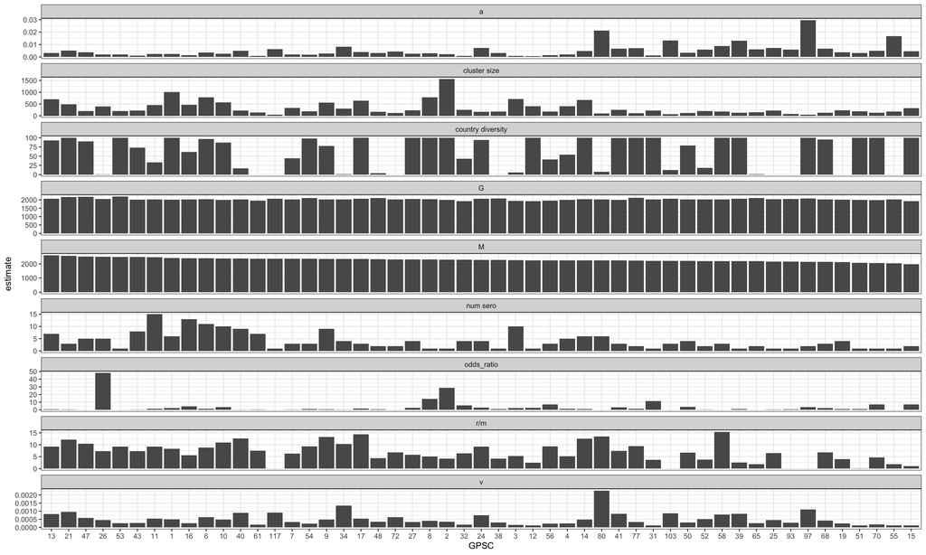

```r
tmp <- fmg_params[fmg_params$param == "M" & fmg_params$method == "strict", ]
tmp <- tmp$GPSC[order(-tmp$estimate)]
tmp <- c(tmp, unique(fmg_params$GPSC[!(fmg_params$GPSC %in% tmp)]))
fmg_params$GPSC <- factor(fmg_params$GPSC, levels = tmp)

ggplot(fmg_params[fmg_params$method == "strict", ], aes(x = GPSC, y = estimate)) +
    geom_col() + facet_wrap(~param, ncol = 1, scales = "free_y") + theme_bw(base_size = 14)
```

```r
fmg_params$param[fmg_params$param == "odds_ratio"] <- "odds ratio"
fmg_params$param[fmg_params$param == "num sero"] <- "unique serotypes"
fmg_data <- dcast(fmg_params, method + GPSC ~ param, value.var = "estimate")
fmg_data <- fmg_data[fmg_data$method == "strict", ]

cor(fmg_data$M, fmg_data$`unique serotypes`, method = "spearman")
```

```
## [1] 0.5315287
```

```r
cor.test(fmg_data$M, fmg_data$`unique serotypes`, method = "spearman")
```

```
##
##  Spearman's rank correlation rho
##
## data:  fmg_data$M and fmg_data$`unique serotypes`
## S = 10353, p-value = 5.983e-05
## alternative hypothesis: true rho is not equal to 0
## sample estimates:
##       rho
## 0.5315287
```

```r
fmg_data <- fmg_data[!is.na(fmg_data$`r/m`), ]
cor(fmg_data$M, fmg_data$`r/m`, method = "spearman")
```

```
## [1] 0.5157262
```

```r
cor.test(fmg_data$M, fmg_data$`r/m`, method = "spearman")
```

```
##
##  Spearman's rank correlation rho
##
## data:  fmg_data$M and fmg_data$`r/m`
## S = 8376, p-value = 0.0002533
## alternative hypothesis: true rho is not equal to 0
## sample estimates:
##       rho
## 0.5157262
```

```r
fmg_data <- dcast(fmg_params, method + GPSC ~ param, value.var = "estimate")
fmg_data <- fmg_data[fmg_data$method == "strict", ]
fmg_data <- fmg_data[!is.na(fmg_data$`odds ratio`), ]

cor(fmg_data$a, fmg_data$`odds ratio`, method = "spearman")
```

```
## [1] -0.2294072
```

```r
cor.test(fmg_data$a, fmg_data$`odds ratio`, method = "spearman")
```

```
##
##  Spearman's rank correlation rho
##
## data:  fmg_data$a and fmg_data$`odds ratio`
## S = 15172, p-value = 0.1439
## alternative hypothesis: true rho is not equal to 0
## sample estimates:
##        rho
## -0.2294072
```

```r
fmg_data <- merge(sig_odds, fmg_data, by.x = "GPSC", by.y = "GPSC")
fmg_data$disease <- fmg_data$log_odds > 0
mylogit <- glm(disease ~ a, data = fmg_data[fmg_data$issig, ], family = "binomial")
summary(mylogit)
```

```
##
## Call:
## glm(formula = disease ~ a, family = "binomial", data = fmg_data[fmg_data$issig,
##     ])
##
## Deviance Residuals:
##     Min       1Q   Median       3Q      Max
## -2.2458  -0.5551   0.4480   0.5662   1.4887
##
## Coefficients:
##             Estimate Std. Error z value Pr(>|z|)
## (Intercept)    3.805      1.713   2.221   0.0263 *
## a           -673.213    340.795  -1.975   0.0482 *
## ---
## Signif. codes:  0 '***' 0.001 '**' 0.01 '*' 0.05 '.' 0.1 ' ' 1
##
## (Dispersion parameter for binomial family taken to be 1)
##
##     Null deviance: 20.597  on 16  degrees of freedom
## Residual deviance: 15.029  on 15  degrees of freedom
## AIC: 19.029
##
## Number of Fisher Scoring iterations: 5
```

We can now make a prettier picture that focuses on these results.

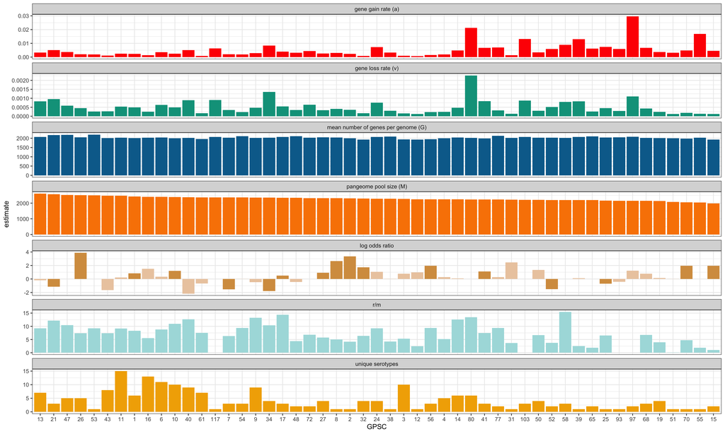

```r
plotdf <- fmg_params[fmg_params$method == "strict", ]
plotdf <- plotdf[plotdf$param %in% c("a", "v", "G", "M", "unique serotypes",
    "odds ratio", "r/m"), ]

library(wesanderson)
library(patchwork)

plotdf$param[plotdf$param == "G"] <- "mean number of genes per genome (G)"
plotdf$param[plotdf$param == "M"] <- "pangeome pool size (M)"
plotdf$param[plotdf$param == "a"] <- "gene gain rate (a)"
plotdf$param[plotdf$param == "v"] <- "gene loss rate (v)"
plotdf$param[plotdf$param == "odds ratio"] <- "log odds ratio"
plotdf$param <- factor(plotdf$param, levels = c("gene gain rate (a)", "gene loss rate (v)",
    "mean number of genes per genome (G)", "pangeome pool size (M)", "log odds ratio",
    "r/m", "unique serotypes"))
plotdf$estimate[plotdf$param == "log odds ratio"] <- log(plotdf$estimate[plotdf$param ==
    "log odds ratio"])
plotdf$param2 <- as.character(plotdf$param)
plotdf$param2[(plotdf$param == "log odds ratio") & (plotdf$GPSC %in% sig_odds$GPSC[sig_odds$issig])] <- "sig"

cols <- c(wes_palette("Darjeeling1")[c(1, 2)], wes_palette("Darjeeling2")[c(1)],
    wes_palette("Darjeeling2")[c(2)], wes_palette("Darjeeling1")[c(4)], wes_palette("Darjeeling2")[c(4)],
    wes_palette("Darjeeling2")[[3]], wes_palette("Darjeeling1")[[3]])

ggplot(plotdf, aes(x = GPSC, y = estimate, fill = param2)) + geom_col() + facet_wrap(~param,
    ncol = 1, scales = "free_y") + theme_bw(base_size = 14) + scale_fill_manual(values = cols) +
    theme(legend.position = "none")
```

We can also focus in on the association between gene gain/loss rates and the log odds ratio of invasive disease

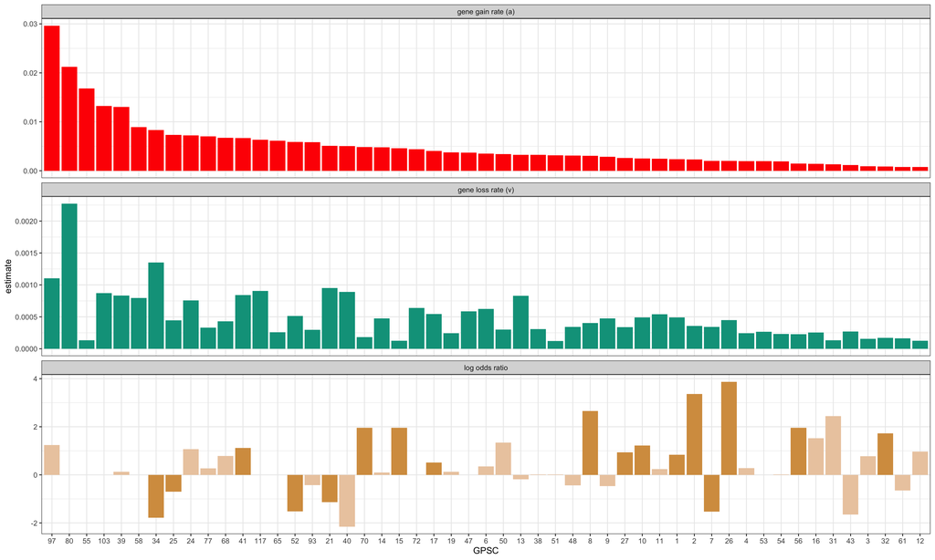

```r
tmp <- plotdf[plotdf$param=="gene gain rate (a)" ,]
tmp <- tmp$GPSC[order(-tmp$estimate)]
plotdf$GPSC <- factor(plotdf$GPSC, levels = tmp)

cols <- c(wes_palette("Darjeeling1")[c(1,2)], #k
          wes_palette("Darjeeling2")[c(1)], #k
          wes_palette("Darjeeling2")[[3]])

ggplot(plotdf[plotdf$param %in% c("gene gain rate (a)", "gene loss rate (v)", 'log odds ratio'),],
       aes(x=GPSC, y=estimate, fill=param2)) +
  geom_col() +
  facet_wrap(~ param, ncol = 1, scales = "free_y") +
  theme_bw(base_size = 14) +
  scale_fill_manual(values = cols) +
  theme(legend.position = "none")
```

### References

Baumdicker, Franz, Wolfgang R Hess, and Peter Pfaffelhuber. 2012. “The Infinitely Many Genes Model for the Distributed Genome of Bacteria.” *Genome Biol. Evol.* 4 (4): 443–56. doi:10.1093/gbe/evs016.

Collins, R Eric, and Paul G Higgs. 2012. “Testing the Infinitely Many Genes Model for the Evolution of the Bacterial Core Genome and Pangenome.” *Mol. Biol. Evol.* 29 (11). Narnia: 3413–25. doi:10.1093/molbev/mss163.

Gladstone, Rebecca A, Stephanie W Lo, John A Lees, Nicholas J Croucher, Andries J van Tonder, Jukka Corander, Andrew J Page, et al. 2019. “International Genomic Definition of Pneumococcal Lineages, to Contextualise Disease, Antibiotic Resistance and Vaccine Impact.” *EBioMedicine* 43 (May). Elsevier: 338–46. doi:10.1016/j.ebiom.2019.04.021.

Zamani-Dahaj, Seyed Alireza, Mohamed Okasha, Jakub Kosakowski, and Paul G Higgs. 2016. “Estimating the Frequency of Horizontal Gene Transfer Using Phylogenetic Models of Gene Gain and Loss.” *Mol. Biol. Evol.* 33 (7): 1843–57. doi:10.1093/molbev/msw062.